# Assignment 2: Spatial Analysis and Visualization

Healthcare Access and Equity in Pennsylvania

Author

Ixchel Ramirez

Published

October 19, 2025

## Part 1: Healthcare Access for Vulnerable Populations

### Research Question

**Which Pennsylvania counties have the highest proportion of vulnerable populations (elderly + low-income) living far from hospitals?**

Your analysis should identify counties that should be priorities for healthcare investment and policy intervention.

### Required Analysis Steps

Complete the following analysis, documenting each step with code and brief explanations:

#### Step 1: Data Collection (5 points)

Load the required spatial data: - Pennsylvania county boundaries - Pennsylvania hospitals (from lecture data) - Pennsylvania census tracts

**Set-up:**

```r
# Load required packages
library(tidyverse)
library(tidycensus)
library(tigris)
library(knitr)
library(sf)
library(dplyr)
library(here)
options(tigris_use_cache = TRUE)
options(tigris_progress = FALSE)

# Load spatial data
pa_counties <- st_read(here("data/Pennsylvania_County_Boundaries.shp"))
census_tracts <- tracts(state = "PA", cb = TRUE, progress = FALSE)
metro_areas <- core_based_statistical_areas(cb = TRUE, progress = FALSE)
# Read GeoJSON
districts <- st_read(here("data/districts.geojson"))
hospitals <- st_read(here("data/hospitals.geojson"))
# Check that all data loaded correctly
st_geometry(pa_counties)
```

```
Geometry set for 67 features
Geometry type: MULTIPOLYGON
Dimension:     XY
Bounding box:  xmin: -8963377 ymin: 4825316 xmax: -8314404 ymax: 5201413
Projected CRS: WGS 84 / Pseudo-Mercator
First 5 geometries:
```

```r
st_geometry(hospitals)
```

```
Geometry set for 223 features
Geometry type: POINT
Dimension:     XY
Bounding box:  xmin: -80.49621 ymin: 39.75163 xmax: -74.86704 ymax: 42.13403
Geodetic CRS:  WGS 84
First 5 geometries:
```

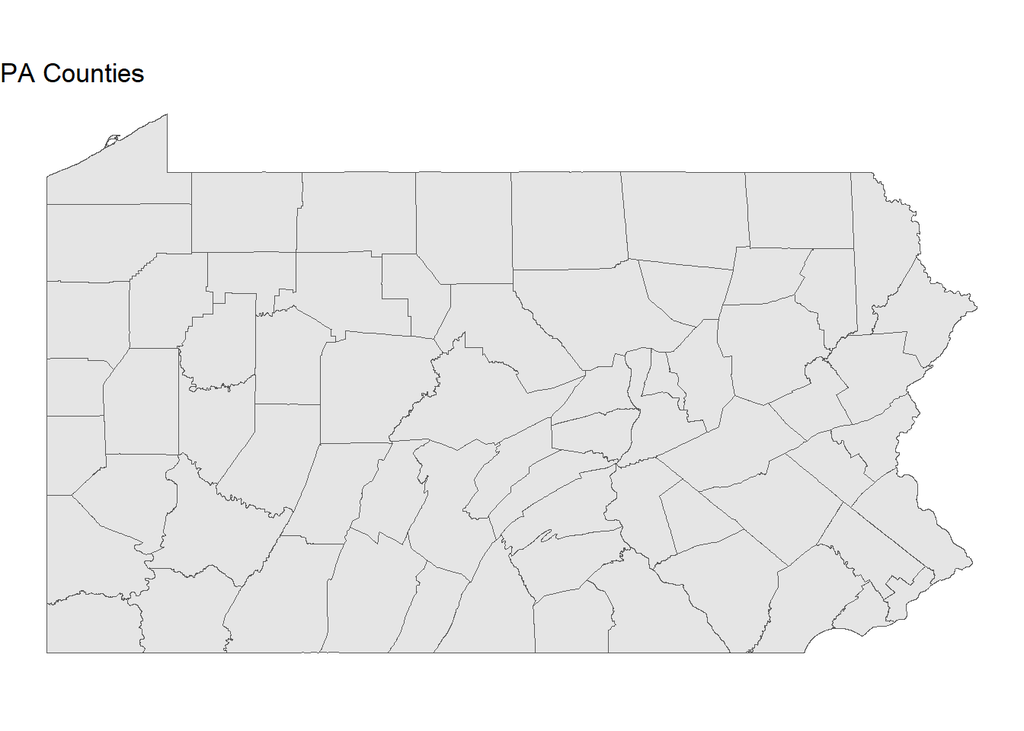

```r
hospitals <- hospitals %>%
  st_transform(st_crs(pa_counties))
census_tracts <- census_tracts %>%
  st_transform(st_crs(pa_counties))
districts <- districts%>%
  st_transform(st_crs(census_tracts))

ggplot(pa_counties) +
  geom_sf() +
  labs(title = "PA Counties") +
  theme_void()
```

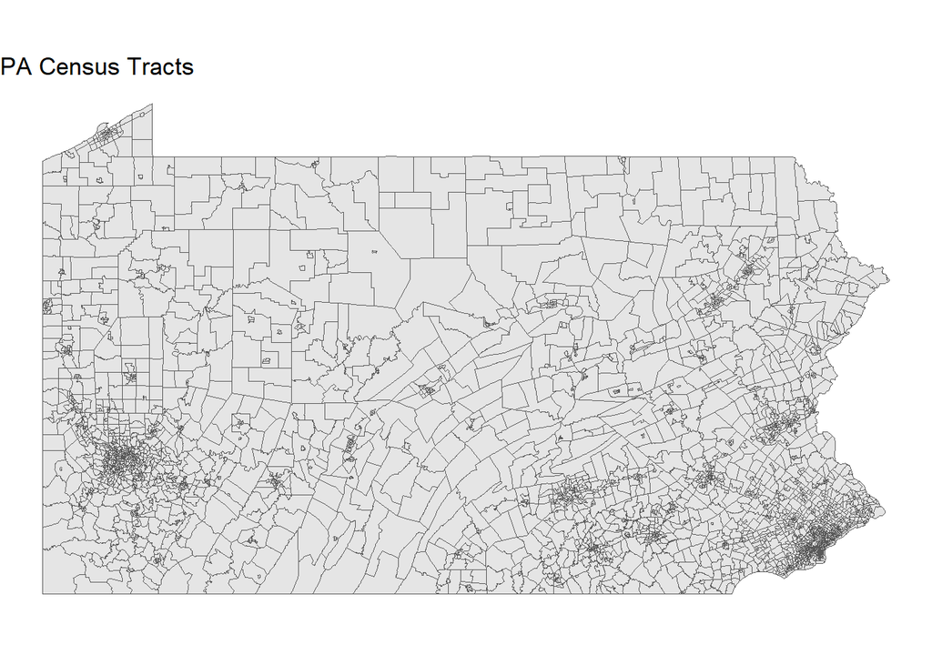

```r
ggplot(census_tracts) +
  geom_sf() +
  labs(title = "PA Census Tracts") +
  theme_void()
```

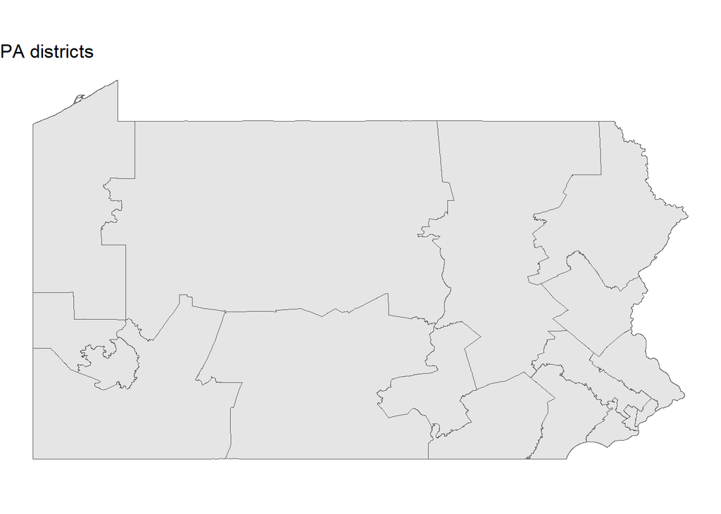

```r
ggplot(districts) +
  geom_sf() +
  labs(title = "PA districts") +
  theme_void()
```

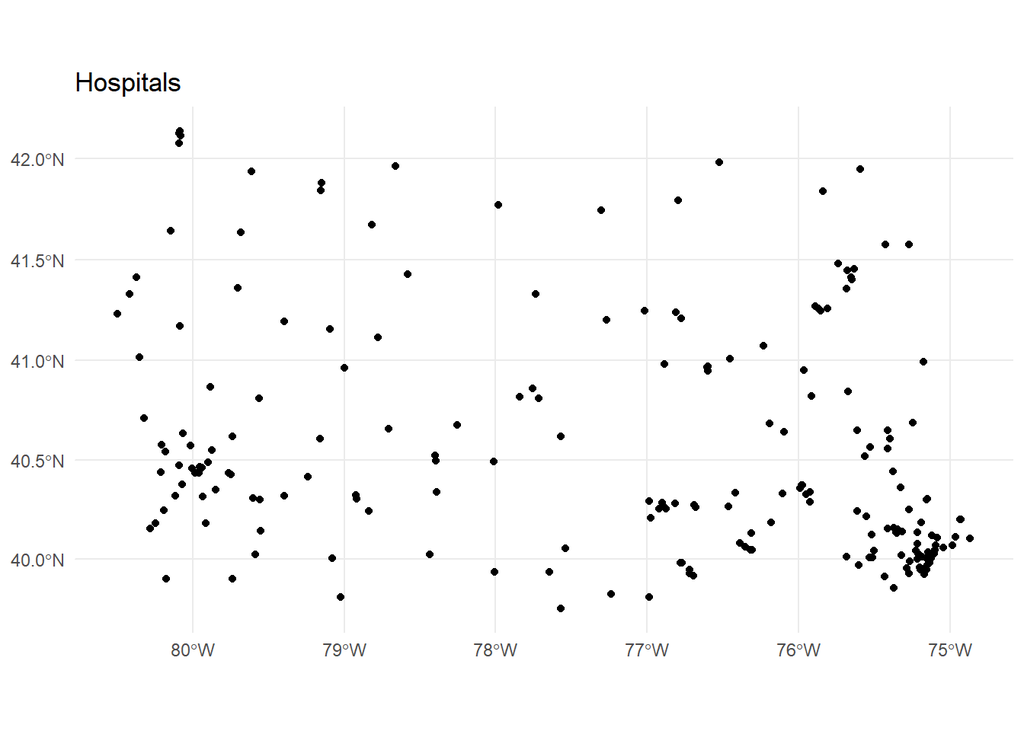

```r
ggplot(hospitals) +
  geom_sf() +
  labs(title = "Hospitals") +
  theme_minimal()
```

**Questions to answer:** - How many hospitals are in your dataset? There are 223 hospitals in my dataset. - How many census tracts? There are 3445 census tracts in Pennsylvania. - What coordinate reference system is each dataset in? The pa_counties is is WGS 84 / Pseudo-Mercator which all datasets have been projeted to.

#### Step 2: Get Demographic Data

**Required variables:** - Total population - Median household income - Population 65 years and over (you may need to sum multiple age categories)

**Loading Demographic Data:**

```r
# Get demographic data from ACS

pa_vars <- c(
  total_pop = "B01001_001",    # Total population
  med_income = "B19013_001",   # Median household income
  male_65_66 = "B01001_020",
  male_67_69 = "B01001_021",
  male_70_74 = "B01001_022",
  male_75_79 = "B01001_023",
  male_80_84 = "B01001_024",
  male_85plus = "B01001_025",
  female_65_66 = "B01001_044",
  female_67_69 = "B01001_045",
  female_70_74 = "B01001_046",
  female_75_79 = "B01001_047",
  female_80_84 = "B01001_048",
  female_85plus = "B01001_049"
)

pa_tracts_raw <- get_acs(
  geography = "tract",
  state = "PA",
  variables = pa_vars,
  year = 2022,
  geometry = TRUE
)

pa_tracts <- pa_tracts_raw %>%
  select(GEOID, variable, estimate, geometry) %>%
  pivot_wider(names_from = variable, values_from = estimate) %>%
  mutate(
    pop_65plus = male_65_66 + male_67_69 + male_70_74 + male_75_79 + male_80_84 + male_85plus +
                 female_65_66 + female_67_69 + female_70_74 + female_75_79 + female_80_84 + female_85plus,
    pct_65plus = 100 * pop_65plus / total_pop
  ) %>%
  st_as_sf()


glimpse(pa_tracts)
```

```
Rows: 3,446
Columns: 18
$ GEOID         <chr> "42001031101", "42013100400", "42013100300", "4201310080…
$ geometry      <MULTIPOLYGON [°]> MULTIPOLYGON (((-77.03108 3..., MULTIPOLYGO…
$ total_pop     <dbl> 5070, 1589, 2873, 1860, 4816, 3464, 6459, 2981, 3997, 34…
$ male_65_66    <dbl> 56, 24, 0, 27, 15, 12, 81, 8, 0, 63, 74, 75, 36, 66, 60,…
$ male_67_69    <dbl> 145, 52, 48, 24, 22, 70, 81, 41, 29, 39, 75, 91, 22, 94,…
$ male_70_74    <dbl> 68, 24, 55, 27, 283, 59, 331, 89, 33, 12, 237, 119, 20, …
$ male_75_79    <dbl> 60, 28, 7, 25, 110, 17, 144, 75, 37, 23, 17, 57, 50, 60,…
$ male_80_84    <dbl> 57, 0, 0, 10, 34, 7, 82, 32, 20, 0, 0, 91, 20, 18, 11, 3…
$ male_85plus   <dbl> 52, 0, 8, 5, 0, 28, 178, 10, 0, 0, 17, 280, 114, 10, 12,…
$ female_65_66  <dbl> 43, 0, 41, 27, 10, 51, 69, 26, 0, 75, 102, 48, 5, 55, 52…
$ female_67_69  <dbl> 141, 45, 51, 28, 17, 27, 314, 71, 64, 16, 109, 28, 37, 6…
$ female_70_74  <dbl> 155, 19, 112, 20, 190, 160, 292, 96, 57, 3, 114, 270, 40…
$ female_75_79  <dbl> 48, 20, 32, 38, 56, 43, 106, 32, 67, 91, 121, 131, 102, …
$ female_80_84  <dbl> 62, 15, 15, 10, 0, 54, 185, 73, 0, 14, 0, 264, 49, 27, 1…
$ female_85plus <dbl> 59, 11, 13, 41, 67, 77, 78, 6, 134, 6, 64, 204, 99, 8, 1…
$ med_income    <dbl> 61847, 67120, 47091, 64583, 21631, 60750, 90603, 97333, …
$ pop_65plus    <dbl> 946, 238, 382, 282, 804, 605, 1941, 559, 441, 342, 930, …
$ pct_65plus    <dbl> 18.658777, 14.977974, 13.296206, 15.161290, 16.694352, 1…
```

```r
summary(pa_tracts$med_income)
```

```
   Min. 1st Qu.  Median    Mean 3rd Qu.    Max.    NA's
  11558   55924   70188   77527   93287  250001      63
```

```r
summary(pa_tracts$pct_65plus)
```

```
   Min. 1st Qu.  Median    Mean 3rd Qu.    Max.    NA's
   0.00   14.26   18.95   19.03   23.11  100.00      32
```

```r
# Join to tract boundaries


sum(is.na(pa_tracts$med_income))
```

```
[1] 63
```

```r
median(pa_tracts$med_income, na.rm = TRUE)
```

```
[1] 70188
```

**Questions to answer:** - What year of ACS data are you using? I am using **2022 5 Year Estimates ACS data** - How many tracts have missing income data? **63** tracts have missing median income data. - What is the median income across all PA census tracts? The median income accross PA census tracts is **$70,188**.

#### Step 3: Define Vulnerable Populations

Identify census tracts with vulnerable populations based on TWO criteria: 1. Low median household income (choose an appropriate threshold) 2. Significant elderly population (choose an appropriate threshold)

**Finding Vulnerable Tracts:**

```r
# Filter for vulnerable tracts based on your criteria

income_threshold <- 56000
elderly_threshold <- 0.25

cat("Income threshold (fixed):", income_threshold, "\n")
```

```
Income threshold (fixed): 56000
```

```r
cat("Elderly threshold (fixed):", elderly_threshold, "%\n")
```

```
Elderly threshold (fixed): 0.25 %
```

```r
# Classify tracts based on both criteria
pa_tracts_vulnerable <- pa_tracts %>%
  mutate(
    low_income = med_income <= income_threshold,
    high_elderly = pct_65plus >= elderly_threshold,
    vulnerable = if_else(low_income & high_elderly, TRUE, FALSE)
  )

# Count how many tracts meet each condition
pa_tracts_vulnerable %>%
  st_drop_geometry() %>%
  summarise(
    n_low_income = sum(low_income, na.rm = TRUE),
    n_high_elderly = sum(high_elderly, na.rm = TRUE),
    n_vulnerable = sum(vulnerable, na.rm = TRUE)
  )
```

```
# A tibble: 1 × 3
  n_low_income n_high_elderly n_vulnerable
         <int>          <int>        <int>
1          850           3401          850
```

#### Step 4: Calculate Distance to Hospitals

For each vulnerable tract, calculate the distance to the nearest hospital.

**Your Task:**

```r
# Use projected CRS in feet
target_crs <- 2272  # Pennsylvania South (ft)
pa_tracts_vulnerable_proj <- st_transform(pa_tracts_vulnerable, target_crs)
hospitals_proj <- st_transform(hospitals, target_crs)

# Compute centroids of vulnerable tracts
tract_vuln <- st_centroid(pa_tracts_vulnerable_proj) %>% filter(vulnerable)

# Find nearest hospital for each vulnerable tract
nearest_hospital_index <- st_nearest_feature(tract_vuln, hospitals_proj)
nearest_hospitals <- hospitals_proj[nearest_hospital_index, ]

# Compute distances in feet, convert to miles
dist_ft <- st_distance(tract_vuln, nearest_hospitals, by_element = TRUE)
tract_vuln$dist_to_hospital_miles <- as.numeric(dist_ft) / 5280

# Summarize distances
avg_dist <- mean(tract_vuln$dist_to_hospital_miles, na.rm = TRUE)
max_dist <- max(tract_vuln$dist_to_hospital_miles, na.rm = TRUE)
over15 <- sum(tract_vuln$dist_to_hospital_miles > 15, na.rm = TRUE)

cat("Average distance to nearest hospital (miles):", round(avg_dist, 2), "\n")
```

```
Average distance to nearest hospital (miles): 3.1
```

```r
cat("Maximum distance (miles):", round(max_dist, 2), "\n")
```

```
Maximum distance (miles): 25.62
```

```r
cat("Number of vulnerable tracts >15 miles from nearest hospital:", over15, "\n")
```

```
Number of vulnerable tracts >15 miles from nearest hospital: 22
```

**Requirements:** - Projections and Calculating distances in miles I used Pennsylvania South projection so I could convert feet to miles.

**Questions to answer:** - What is the average distance to the nearest hospital for vulnerable tracts? 3.1 miles - What is the maximum distance? The maximum distance is 25.62 miles. - How many vulnerable tracts are more than 15 miles from the nearest hospital? There are 22 vulnerable tracts that are more than 15 miles from the nearest hospital.

#### Step 5: Identify Underserved Areas

Define “underserved” as vulnerable tracts that are more than 15 miles from the nearest hospital.

**Your Task:**

```r
# Create underserved variable
tract_vuln <- tract_vuln %>%
  mutate(
    underserved = dist_to_hospital_miles > 15
  )

num_underserved <- sum(tract_vuln$underserved, na.rm = TRUE)
total_vulnerable <- nrow(tract_vuln)
pct_underserved <- (num_underserved / total_vulnerable) * 100
```

**Questions to answer:** - How many tracts are underserved? 22 are underserved - What percentage of vulnerable tracts are underserved? 2.60% of vulnerable tracts are underserved - Does this surprise you? Why or why not? I am pleasantly surprised that there is not a higher percentage of vulnerable tracts that are underserved especially with regards to income being a factor as this limits where one can live. —

#### Step 6: Aggregate to County Level

Use spatial joins and aggregation to calculate county-level statistics about vulnerable populations and hospital access.

**Your Task:**

```r
# Spatial join tracts to counties
pa_counties_proj <- st_transform(pa_counties, st_crs(tract_vuln))

tracts_county <- st_join(
  tract_vuln,
  pa_counties_proj %>% select(COUNTY_NAM),
  join = st_within
)

# Aggregate statistics by county

county_stats <- tracts_county %>%
  st_drop_geometry() %>%
  group_by(COUNTY_NAM) %>%
  summarise(
    n_vulnerable_tracts = n(),
    n_underserved_tracts = sum(underserved, na.rm = TRUE),
    pct_underserved = 100 * n_underserved_tracts / n_vulnerable_tracts,
    avg_dist_miles = mean(dist_to_hospital_miles, na.rm = TRUE),
    total_vulnerable_pop = sum(pop_65plus, na.rm = TRUE)
  ) %>%
  arrange(desc(pct_underserved))

top5_pct_underserved <- county_stats %>%
  slice_max(pct_underserved, n = 5) %>%
  select(COUNTY_NAM, pct_underserved, n_vulnerable_tracts, n_underserved_tracts)

top5_pct_underserved
```

```
# A tibble: 6 × 4
  COUNTY_NAM pct_underserved n_vulnerable_tracts n_underserved_tracts
  <chr>                <dbl>               <int>                <int>
1 CAMERON              100                     1                    1
2 FOREST               100                     2                    2
3 SULLIVAN             100                     1                    1
4 MONROE                66.7                   3                    2
5 JUNIATA               50                     2                    1
6 POTTER                50                     4                    2
```

```r
# View top 5 counties by total vulnerable population
top5_vulnerable_pop <- county_stats %>%
  slice_max(total_vulnerable_pop, n = 5) %>%
  select(COUNTY_NAM, total_vulnerable_pop, n_underserved_tracts)

top5_vulnerable_pop
```

```
# A tibble: 5 × 3
  COUNTY_NAM   total_vulnerable_pop n_underserved_tracts
  <chr>                       <dbl>                <int>
1 PHILADELPHIA                99676                    0
2 ALLEGHENY                   49662                    0
3 LUZERNE                     21876                    0
4 FAYETTE                     14733                    0
5 WESTMORELAND                13989                    0
```

Use spatial joins and aggregation to calculate county-level statistics about vulnerable populations and hospital access.

**Your Task:**

```r
#Spatial Understanding of where vulnerable counties are

pa_counties_proj <- st_transform(pa_counties, st_crs(tract_vuln))

tracts_county <- st_join(
  tract_vuln,
  pa_counties_proj %>% select(COUNTY_NAM),
  join = st_within
)

# Convert underserved to numeric so sum() works
tracts_county <- tracts_county %>%
  mutate(underserved_num = ifelse(underserved, 1, 0))

# Aggregate statistics by county
county_stats <- tracts_county %>%
  st_drop_geometry() %>%
  group_by(COUNTY_NAM) %>%
  summarise(
    n_vulnerable_tracts = n(),
    n_underserved_tracts = sum(underserved_num, na.rm = TRUE),
    pct_underserved = 100 * n_underserved_tracts / n_vulnerable_tracts,
    avg_dist_miles = mean(dist_to_hospital_miles, na.rm = TRUE),
    total_vulnerable_pop = sum(pop_65plus, na.rm = TRUE)
  ) %>%
  arrange(desc(pct_underserved))

# View top 5 counties by pct underserved
top5_pct_underserved <- county_stats %>%
  slice_max(pct_underserved, n = 5) %>%
  select(COUNTY_NAM, pct_underserved, n_vulnerable_tracts, n_underserved_tracts)

top5_pct_underserved
```

```
# A tibble: 6 × 4
  COUNTY_NAM pct_underserved n_vulnerable_tracts n_underserved_tracts
  <chr>                <dbl>               <int>                <dbl>
1 CAMERON              100                     1                    1
2 FOREST               100                     2                    2
3 SULLIVAN             100                     1                    1
4 MONROE                66.7                   3                    2
5 JUNIATA               50                     2                    1
6 POTTER                50                     4                    2
```

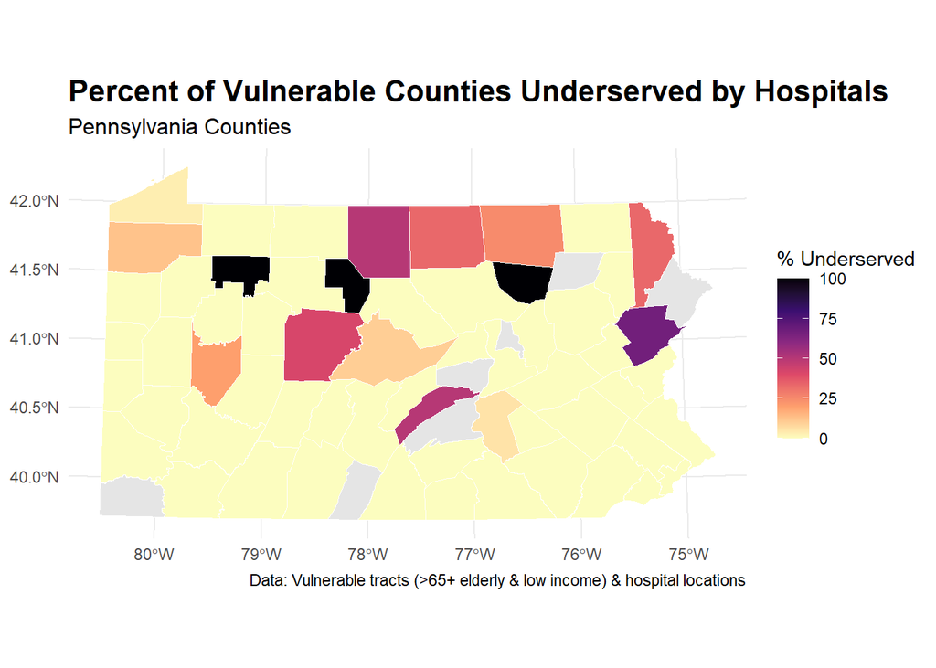

```r
#to understand spatial patterns
library(ggplot2)

pa_counties_plot <- pa_counties_proj %>%
  left_join(county_stats, by = "COUNTY_NAM")

# Map: percent of vulnerable tracts that are underserved
ggplot(pa_counties_plot) +
  geom_sf(aes(fill = pct_underserved), color = "white") +
  scale_fill_viridis_c(option = "magma", direction = -1,
                       na.value = "grey90", name = "% Underserved") +
  labs(
    title = "Percent of Vulnerable Counties Underserved by Hospitals",
    subtitle = "Pennsylvania Counties",
    caption = "Data: Vulnerable tracts (>65+ elderly & low income) & hospital locations"
  ) +
  theme_minimal() +
  theme(
    plot.title = element_text(face = "bold", size = 16),
    plot.subtitle = element_text(size = 12)
  )
```

**Required county-level statistics:** - Number of vulnerable tracts - Number of underserved tracts  
- Percentage of vulnerable tracts that are underserved - Average distance to nearest hospital for vulnerable tracts - Total vulnerable population

**Questions to answer:** - Which 5 counties have the highest percentage of underserved vulnerable tracts? CAMERON  
FOREST  
SULLIVAN  
MONROE  
JUNIATA  
POTTER

#### Step 7: Create Summary Table

Create a professional table showing the top 10 priority counties for healthcare investment.

**Your Task:**

```r
# Create and format priority counties table
county_stats_2 <- county_stats %>%
  mutate(
    priority_score = n_vulnerable_tracts * 0.6 + total_vulnerable_pop * 0.4  # example weighting
  )

library(scales)

# Select top 10 priority counties
top10_priority <- county_stats_2 %>%
  arrange(desc(priority_score)) %>%
  slice(1:10) %>%
  select(
    County = COUNTY_NAM,
    `Vulnerable & Remote Tracts` = n_vulnerable_tracts,
    `Total Vulnerable Population` = total_vulnerable_pop,
    `Priority Score` = priority_score
  ) %>%
  mutate(
    `Total Vulnerable Population` = comma(`Total Vulnerable Population`),
    `Priority Score` = round(`Priority Score`, 1)
  )


# Display professional table
kable(
  top10_priority,
  caption = "Top 10 Priority Counties for Healthcare Investment in Pennsylvania",
  align = c("l", "c", "c", "c"),
  digits = 0
)
```

Top 10 Priority Counties for Healthcare Investment in Pennsylvania

[output not shown]

## Part 2: Comprehensive Visualization

### Map 1: County-Level Choropleth

Create a choropleth map showing healthcare access challenges at the county level.

**Your Task:**

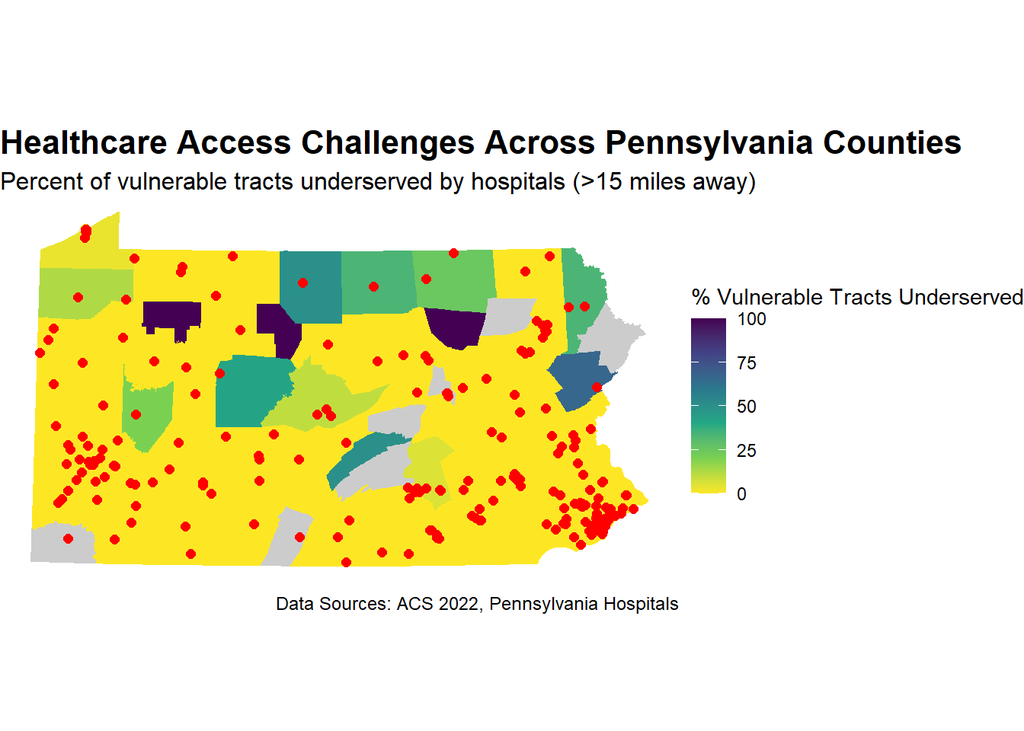

```r
# Create county-level access map

library(viridis)

# Merge county statistics back to county geometries
pa_counties_plot <- pa_counties_proj %>%
  left_join(county_stats_2, by = c("COUNTY_NAM"))

# Map: percent of vulnerable tracts underserved with hospital locations
ggplot(pa_counties_plot) +
  # Counties filled by percent underserved
  geom_sf(aes(fill = pct_underserved), color = "transparent") +

  # Hospitals as points
  geom_sf(data = hospitals_proj, color = "red", size = 2, shape = 21, fill = "red") +

  # Color scale
  scale_fill_viridis_c(
    option = "Blues",
    direction = -1,
    na.value = "grey80",
    name = "% Vulnerable Tracts Underserved"
  ) +

  # Titles and caption
  labs(
    title = "Healthcare Access Challenges Across Pennsylvania Counties",
    subtitle = "Percent of vulnerable tracts underserved by hospitals (>15 miles away)",
    caption = "Data Sources: ACS 2022, Pennsylvania Hospitals"
  ) +

  # Clean theme
  theme_void() +
  theme(
    plot.title = element_text(face = "bold", size = 16),
    plot.subtitle = element_text(size = 12),
    plot.caption = element_text(size = 9),
    legend.position = "right"
  )
```

### Map 2: Detailed Vulnerability Map

Create a map highlighting underserved vulnerable tracts.

**Your Task:**

```r
# Create distribution visualization
### Map 2: Detailed Vulnerability Map (Robust Version)
tract_vuln <- tract_vuln %>%
  filter(!st_is_empty(geometry)) %>%
  st_make_valid()

pa_counties_proj <- pa_counties_proj %>%
  filter(!st_is_empty(geometry)) %>%
  st_make_valid()

hospitals_proj <- hospitals_proj %>%
  filter(!st_is_empty(geometry)) %>%
  st_make_valid()

tracts_vulnerable_only <- tract_vuln %>%
  filter(vulnerable == TRUE) %>%
  st_as_sf()

tracts_underserved <- tract_vuln %>%
  filter(underserved == TRUE) %>%
  st_as_sf()


st_is_valid(tracts_vulnerable_only) %>% table()
```

```
.
TRUE
 850
```

```r
tracts_vulnerable_only <- tracts_vulnerable_only %>%
  filter(!st_is_empty(geometry), !is.na(st_dimension(geometry)))
nrow(tracts_vulnerable_only)
```

```
[1] 850
```

```r
sum(st_is_empty(tracts_vulnerable_only))
```

```
[1] 0
```

```r
class(tracts_vulnerable_only)
```

```
[1] "sf"         "tbl_df"     "tbl"        "data.frame"
```

```r
st_geometry(tracts_vulnerable_only)
```

```
Geometry set for 850 features
Geometry type: POINT
Dimension:     XY
Bounding box:  xmin: 1207878 ymin: 155878.3 xmax: 2750201 ymax: 1032054
Projected CRS: NAD83 / Pennsylvania South (ftUS)
First 5 geometries:
```

```r
#trial plot

st_geometry(census_tracts)
```

```
Geometry set for 3445 features
Geometry type: MULTIPOLYGON
Dimension:     XY
Bounding box:  xmin: -8963433 ymin: 4825308 xmax: -8314399 ymax: 5201489
Projected CRS: WGS 84 / Pseudo-Mercator
First 5 geometries:
```

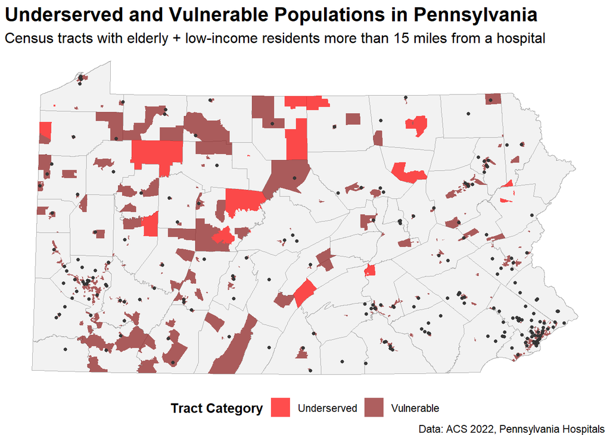

```r
tracts_vulnerable_only <- census_tracts %>%
  left_join(tracts_vulnerable_only %>% st_drop_geometry(), by = "GEOID") %>%
  filter(vulnerable == TRUE)

#refinement
tracts_vulnerable_only <- tracts_vulnerable_only %>%
  mutate(category = case_when(
    underserved == TRUE ~ "Underserved",
    vulnerable == TRUE ~ "Vulnerable",
    TRUE ~ "Other"
  ))


ggplot() +
  geom_sf(data = pa_counties_proj, fill = "grey95", color = "darkgrey", size = 0.2) +
  geom_sf(data = tracts_vulnerable_only, aes(fill = category), color = NA, alpha = 0.7) +
  geom_sf(data = hospitals_proj, color = "grey18", fill = "grey22", shape = 21, size = 1) +
  scale_fill_manual(
    values = c(
      "Underserved" = "red",
      "Vulnerable" = "firebrick4",
      "Other" = "grey90"
    ),
    name = "Tract Category"
  ) +
  labs(
    title = "Underserved and Vulnerable Populations in Pennsylvania",
    subtitle = "Census tracts with elderly + low-income residents more than 15 miles from a hospital",
    caption = "Data: ACS 2022, Pennsylvania Hospitals"
  ) +
  theme_void() +
  theme(
    plot.title = element_text(face = "bold", size = 16),
    plot.subtitle = element_text(size = 12),
    legend.position = "bottom",
    legend.title = element_text(face = "bold"),
    panel.grid = element_blank()
  )
```

**Requirements:** I used a bright red to distinguish underserved vulnerable tracts, which are easy to see in contrast to the other tracts and the hospitals which are all darker tones.

### Chart: Distribution Analysis

Create a visualization showing the distribution of distances to hospitals for vulnerable populations.

**Your Task:**

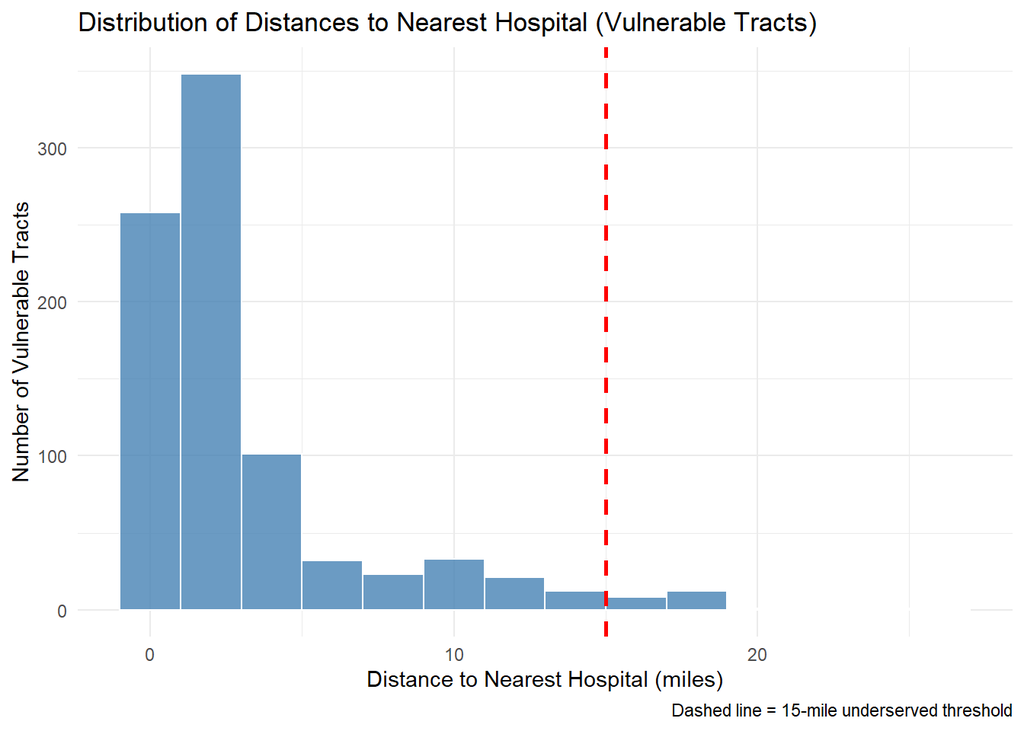

```r
# Create distribution visualization

ggplot(tract_vuln, aes(x = dist_to_hospital_miles)) +
  geom_histogram(binwidth = 2, fill = "steelblue", color = "white", alpha = 0.8) +
  geom_vline(xintercept = 15, linetype = "dashed", color = "red", size = 1) +
  labs(
    title = "Distribution of Distances to Nearest Hospital (Vulnerable Tracts)",
    x = "Distance to Nearest Hospital (miles)",
    y = "Number of Vulnerable Tracts",
    caption = "Dashed line = 15-mile underserved threshold"
  ) +
  theme_minimal()
```

**Requirements:** - Brief interpretation Most vulnerable tracts are within a 15 miles of a hospital, a small portion of them are further than 15 miles from a hospital.

## Part 3: Bring Your Own Data Analysis

### Your Analysis

**Your Task:**

**Option B: School Safety Zones** - **Data:** Schools, Crime Incidents, Bike Network - **Question:** “Are school zones safe for walking/biking, or are they crime hotspots?” - **Operations:** Buffer schools (1000ft safety zone), spatial join with crime incidents, assess bike infrastructure coverage - **Policy relevance:** Safe Routes to School programs, crossing guard placement

1. All three data sets come from **OpenDataPhilly:** https://opendataphilly.org/datasets/ **Find and load additional data**
   - Document your data source
   - Check and standardize the CRS
   - Provide basic summary statistics

```r
# Load your additional dataset

schools <- st_read(here("data/Schools.geojson"))
crime <- st_read(here("data/incidents_part1_part2.shp"))
```

```
replacing null geometries with empty geometries
Simple feature collection with 122811 features and 13 fields (with 3146 geometries empty)
Geometry type: POINT
Dimension:     XY
Bounding box:  xmin: -75.27421 ymin: 5.684342e-14 xmax: 5.684342e-14 ymax: 40.13683
Geodetic CRS:  WGS 84
```

```r
bikenetwork <- st_read(("data/Bike_Network.geojson"))
target_crs <- st_crs(2272)
schools <- st_transform(schools, target_crs)
crime <- st_transform(crime, target_crs)
bikenetwork <- st_transform(bikenetwork, target_crs)

summary(schools)
```

```
      aun              school_num   location_id        school_name
 Min.   :100510000   Min.   :3445   Length:495         Length:495
 1st Qu.:126515001   1st Qu.:3752   Class :character   Class :character
 Median :126515001   Median :6527   Mode  :character   Mode  :character
 Mean   :163032553   Mean   :5776
 3rd Qu.:226511157   3rd Qu.:7664
 Max.   :326517786   Max.   :8493
 NA's   :51          NA's   :208
 school_name_label  street_address       zip_code         phone_number
 Length:495         Length:495         Length:495         Length:495
 Class :character   Class :character   Class :character   Class :character
 Mode  :character   Mode  :character   Mode  :character   Mode  :character




 grade_level         grade_org           enrollment          type
 Length:495         Length:495         Min.   :   1.0   Min.   :1.000
 Class :character   Class :character   1st Qu.: 270.0   1st Qu.:1.000
 Mode  :character   Mode  :character   Median : 446.0   Median :1.000
                                       Mean   : 548.5   Mean   :1.768
                                       3rd Qu.: 656.0   3rd Qu.:3.000
                                       Max.   :3467.0   Max.   :3.000
                                       NA's   :162
 type_specific         objectid              geometry
 Length:495         Min.   :  1.0   POINT        :495
 Class :character   1st Qu.:124.5   epsg:2272    :  0
 Mode  :character   Median :248.0   +proj=lcc ...:  0
                    Mean   :248.0
                    3rd Qu.:371.5
                    Max.   :495.0
```

```r
summary(crime)
```

```
    objectid          dc_dist              psa              dispatch_d
 Min.   :24039329   Length:122811      Length:122811      Min.   :2025-01-01
 1st Qu.:27844661   Class :character   Class :character   1st Qu.:2025-03-26
 Median :30309477   Mode  :character   Mode  :character   Median :2025-06-06
 Mean   :29829120                                         Mean   :2025-06-01
 3rd Qu.:32628090                                         3rd Qu.:2025-08-11
 Max.   :32887806                                         Max.   :2025-10-19

  dispatch_1         dispatch_t             hour           dc_key
 Length:122811      Length:122811      Min.   : 0.00   Min.   :2.023e+11
 Class :character   Class :character   1st Qu.: 9.00   1st Qu.:2.025e+11
 Mode  :character   Mode  :character   Median :13.00   Median :2.025e+11
                                       Mean   :13.07   Mean   :2.042e+11
                                       3rd Qu.:17.00   3rd Qu.:2.025e+11
                                       Max.   :23.00   Max.   :2.025e+14

  location_b         ucr_genera         text_gener           point_x
 Length:122811      Length:122811      Length:122811      Min.   :    -75.3
 Class :character   Class :character   Class :character   1st Qu.:    -75.2
 Mode  :character   Mode  :character   Mode  :character   Median :    -75.2
                                                          Mean   :   7552.7
                                                          3rd Qu.:    -75.1
                                                          Max.   :2746280.6
                                                          NA's   :3144
    point_y                   geometry
 Min.   :     0.00   POINT        :122811
 1st Qu.:    39.96   epsg:2272    :     0
 Median :    39.99   +proj=lcc ...:     0
 Mean   :   754.17
 3rd Qu.:    40.03
 Max.   :301244.66
 NA's   :3144
```

```r
summary(bikenetwork)
```

```
    OBJECTID        SEG_ID         STREETNAME           ST_CODE
 Min.   :   1   Min.   : 100002   Length:5225        Min.   : 9205
 1st Qu.:1307   1st Qu.: 400465   Class :character   1st Qu.:41240
 Median :2613   Median : 500410   Mode  :character   Median :64820
 Mean   :2613   Mean   : 542578                      Mean   :59609
 3rd Qu.:3919   3rd Qu.: 721062                      3rd Qu.:81600
 Max.   :5225   Max.   :1180077                      Max.   :89710
    ONEWAY              CLASS           TYPE           Shape__Length
 Length:5225        Min.   :2.000   Length:5225        Min.   :   6.267
 Class :character   1st Qu.:2.000   Class :character   1st Qu.:  70.212
 Mode  :character   Median :3.000   Mode  :character   Median : 103.781
                    Mean   :2.929                      Mean   : 137.857
                    3rd Qu.:4.000                      3rd Qu.: 177.150
                    Max.   :9.000                      Max.   :1673.993
          geometry
 LINESTRING   :5225
 epsg:2272    :   0
 +proj=lcc ...:   0
```

**Questions to answer:** - What dataset did you choose and why? The datasets I used are Crime Incidents, Bike Network and Schools from OpenDataPhilly.

- What is the data source and date? The data source is OpenDataPhilly and it was accessed on October 19.
- How many features does it contain? Bikenetwork contains 9 variables, crime contains 14 variables and schools contains 15 variables.
- What CRS is it in? Did you need to transform it? The CRS was WGS 84, I transformed it for additional practice but they were all in the same coordinate reference system. —
2. **Pose a research question** Are school zones safe for walking/biking, or are they crime hotspots?
3. **Conduct spatial analysis**

I am using buffers and spatial joins to complete my analysis.

**Your Task: Setting up the Data**

```r
# Your spatial analysis

school_buffers <- st_buffer(schools, dist = 1000)  # creates a 1000 ft safety zone around schools

school_buffers <- school_buffers %>%
  rename(school_id = objectid) #rename the school ids so the columns have different names

crime <- crime %>%
  rename(crime_id = objectid)
school_crime_counts <- st_join(school_buffers, crime, join = st_contains) %>%
  group_by(school_id, school_name) %>%  # Use unique school ID
  summarise(
    n_crimes = n(),
    .groups = "drop"
  )

#including the coverage of the bike network in Philly
bike_in_buffers <- st_intersection(bikenetwork, school_buffers)

bike_length_per_school <- bike_in_buffers %>%
  group_by(school_id, school_name) %>%
  summarise(
    bike_length_ft = sum(st_length(geometry)),
    .groups = "drop"
  )

#Bringing all the data together
# Drop geometry for bike summary
bike_length_per_school_df <- bike_length_per_school %>%
  st_drop_geometry()

# Now join safely
school_safety_summary <- school_crime_counts %>%
  left_join(bike_length_per_school_df, by = c("school_id", "school_name")) %>%
  mutate(bike_length_ft = ifelse(is.na(bike_length_ft), 0, bike_length_ft))

#Map of findings
library(ggplot2)
library(scales)

school_crime_counts_df <- st_drop_geometry(school_crime_counts)

# Merge crime counts to school buffers for plotting
school_buffers_plot <- school_buffers %>%
  left_join(school_crime_counts_df, by = c("school_id", "school_name"))

school_buffers_plot <- school_buffers_plot %>%
  mutate(n_crimes = ifelse(is.na(n_crimes), 0, n_crimes))

# Highlight variation (e.g., sqrt)
school_buffers_plot <- school_buffers_plot %>%
  mutate(n_crimes_sqrt = sqrt(n_crimes))
```

**Mapping**

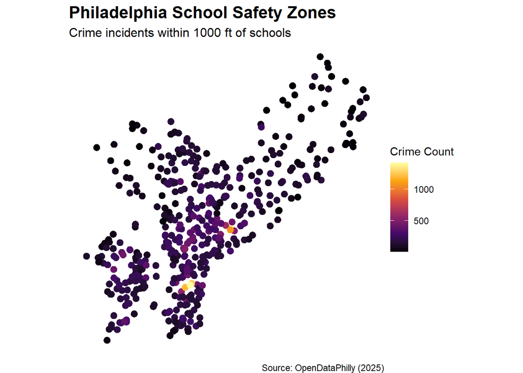

```r
# Your spatial analysis

ggplot(school_buffers_plot) +
  geom_sf(aes(fill = n_crimes), color = NA) +
  scale_fill_viridis_c(option = "inferno", name = "Crime Count") +
  labs(
    title = "Philadelphia School Safety Zones",
    subtitle = "Crime incidents within 1000 ft of schools",
    caption = "Source: OpenDataPhilly (2025)"
  ) +
  theme_void() +
  theme(
    legend.position = "right",
    plot.title = element_text(face = "bold", size = 16),
    plot.subtitle = element_text(size = 12)
  )
```

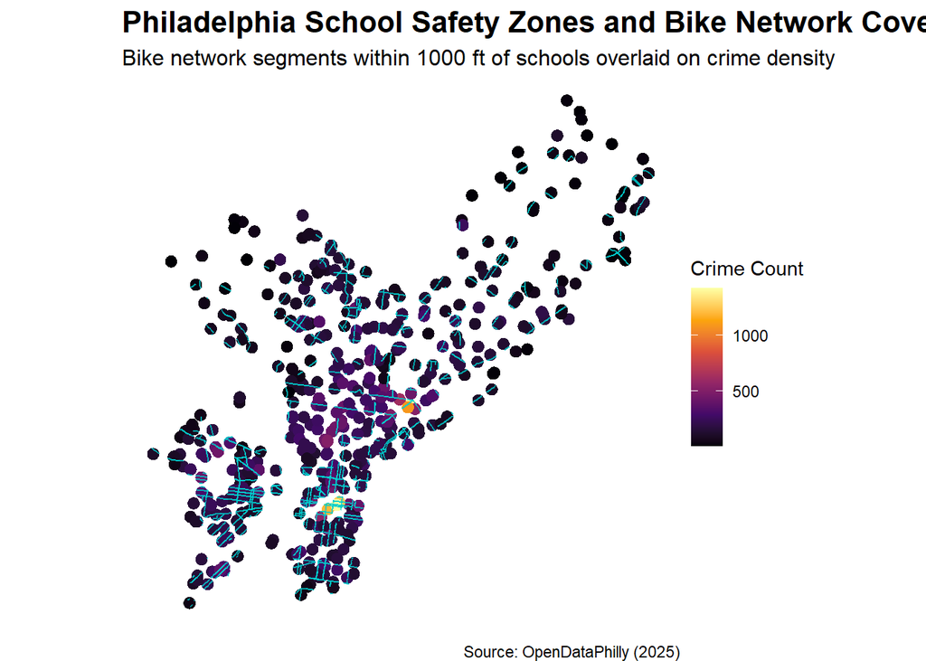

```r
# Ensure both layers have the same CRS
bikenetwork <- st_transform(bikenetwork, st_crs(school_buffers_plot))

# --- 1. Intersect bike network with school buffers ---
# This keeps only the bike segments that fall within 1000 ft of schools
bike_in_buffers <- st_intersection(bikenetwork, school_buffers_plot)

# --- 2. Map: Crime gradient + bike network inside buffers ---
ggplot() +
  # School buffer polygons shaded by number of crimes
  geom_sf(data = school_buffers_plot, aes(fill = n_crimes), color = NA) +

  # Bike network segments within buffers (cyan lines)
  geom_sf(
    data = bike_in_buffers,
    color = "cyan3",
    size = 0.6,
    alpha = 0.8
  ) +

  # Color scale for crime density
  scale_fill_viridis_c(option = "inferno", name = "Crime Count") +

  # Titles and labels
  labs(
    title = "Philadelphia School Safety Zones and Bike Network Coverage",
    subtitle = "Bike network segments within 1000 ft of schools overlaid on crime density",
    caption = "Source: OpenDataPhilly (2025)"
  ) +

  # Minimal map style
  theme_void() +
  theme(
    legend.position = "right",
    plot.title = element_text(face = "bold", size = 16),
    plot.subtitle = element_text(size = 12)
  )
```

**Summary Statistics and Counts**

```r
# Summary Statistics for School Safety Analysis

# 1. Total number of schools analyzed
n_schools <- nrow(school_crime_counts)

# 2. Total number of crimes within 1000 ft of schools
total_crimes <- sum(school_crime_counts$n_crimes, na.rm = TRUE)

# 3. Average number of crimes per school buffer
avg_crimes_per_school <- mean(school_crime_counts$n_crimes, na.rm = TRUE)

# 4. Number (and percent) of schools with *zero* nearby crimes
schools_no_crime <- sum(school_crime_counts$n_crimes == 0, na.rm = TRUE)
pct_no_crime <- round(100 * schools_no_crime / n_schools, 1)

# 5. Bike network coverage summary
total_bike_length <- sum(bike_length_per_school$bike_length_ft, na.rm = TRUE)
avg_bike_length <- mean(bike_length_per_school$bike_length_ft, na.rm = TRUE)

#simple summary table
summary_table <- data.frame(
  Metric = c(
    "Total schools analyzed",
    "Total crimes within 1000 ft",
    "Average crimes per school",
    "Schools with no nearby crimes",
    "Percent of schools with no nearby crimes",
    "Total bike network length within 1000 ft (ft)",
    "Average bike network length per school (ft)"
  ),
  Value = c(
    n_schools,
    total_crimes,
    round(avg_crimes_per_school, 1),
    schools_no_crime,
    paste0(pct_no_crime, "%"),
    round(total_bike_length, 0),
    round(avg_bike_length, 0)
  )
)

# Display the table nicely
library(knitr)
kable(summary_table, caption = "Summary of School Zone Safety and Bike Access in Philadelphia")
```

Summary of School Zone Safety and Bike Access in Philadelphia

| Metric | Value |
| --- | --- |
| Total schools analyzed | 495 |
| Total crimes within 1000 ft | 87665 |
| Average crimes per school | 177.1 |
| Schools with no nearby crimes | 0 |
| Percent of schools with no nearby crimes | 0% |
| Total bike network length within 1000 ft (ft) | 1092609 |
| Average bike network length per school (ft) | 2759 |

**Analysis requirements:** - Clear code comments explaining each step - Appropriate CRS transformations - Summary statistics or counts - At least one map showing your findings - Brief interpretation of results (3-5 sentences)

**Your interpretation:** School zones are generally safe for biking and walking. Only 3 of the points in the 1000ft of school buffers have a 1000 or more crime incidents. The average number of crimes per school is 177 which is 0.14% of the crimes in Philadelphia. Since Philadelphia has 495 located throughout the city, this accounts for the high number for total crimes within 1000 feet of a school, which means it is more helpful to look at general trends of crime per school than this number alone.

## Incorporation of feedback!

I deleted additional instructions and added additional headers to help with readability.